# Example of bootstrap analysis

Clay Ford

12/10/2021

## Generate data

First generate some skewed data that’s also multimodal.

```r
set.seed(9)
n <- 180
need1 <- sample(1:6, size = n/2, replace = TRUE, prob = c(1, 1, 1, 3, 4, 3)/14)
need2 <- sample(1:6, size = n/2, replace = TRUE, prob = c(1, 1, 1, 4, 5, 4)/16)
grp <- rep(c("ctrl", "int"), each = n/2)
d <- data.frame(grp, need = c(need1, need2))
```

## Visualize data

The default `geom_density` settings make the data look multimodal because it’s trying very hard to interpolate between discrete values. Therefore it looks quite wiggly.

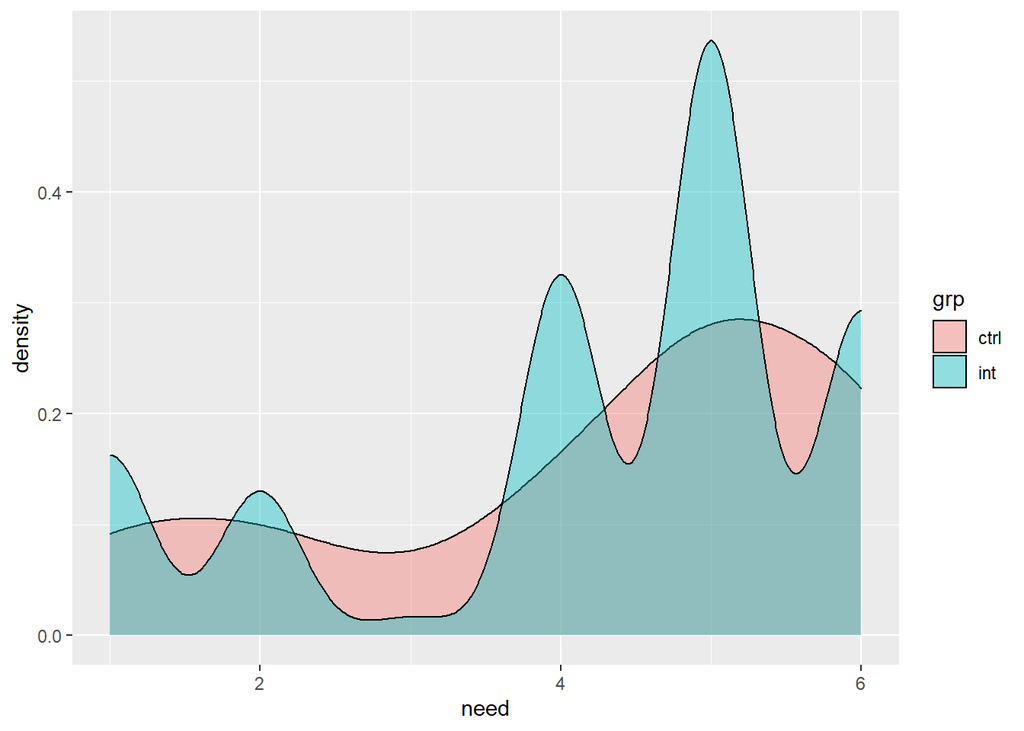

```r
library(ggplot2)
ggplot(d) +
  aes(x = need, fill = grp) +
  geom_density(alpha = 0.4)
```

However we can adjust the bandwidth using the `adjust` argument to make the lines smoother. This basically says “don’t try so hard to imagine what’s between the discrete values.” Higher values lead to smoother estimates.

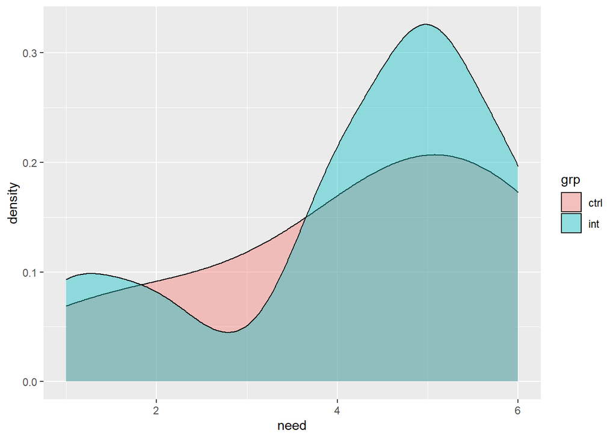

```r
ggplot(d) +
  aes(x = need, fill = grp) +
  geom_density(alpha = 0.4, adjust = 2)
```

A better plot might just be a bar plot since the data is discrete. A density plot is usually better suited for continuous data (ie, data with decimals)

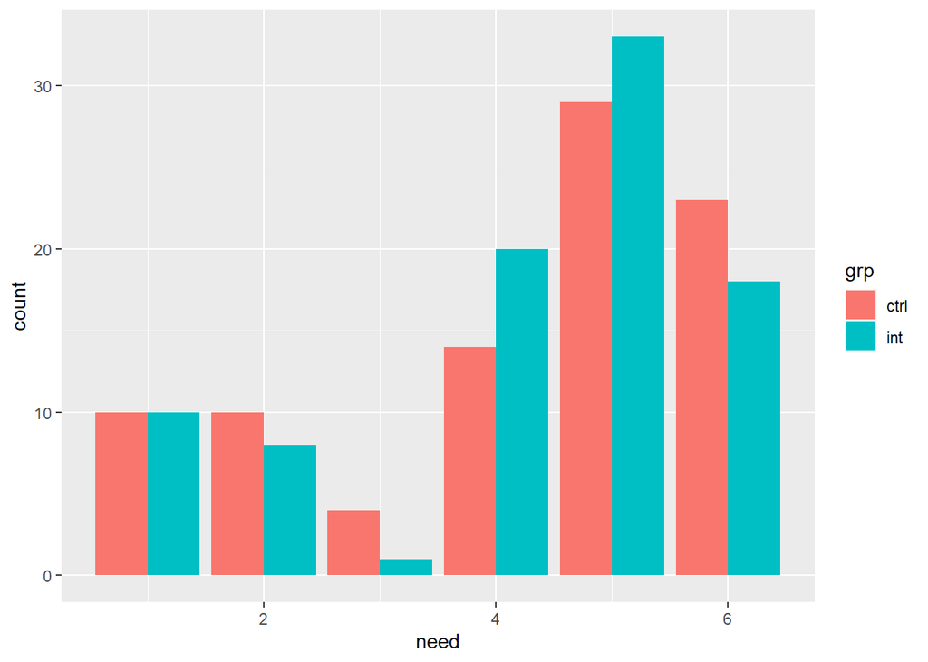

```r
ggplot(d) +
  aes(x = need, fill = grp) +
  geom_bar(position = "dodge")
```

These last two plots reveal the data is indeed skewed and perhaps bi-modal, but it definitely gives us a different impression that the first plot.

## Summarize data

Compare means and medians. Very similar.

```r
tapply(d$need, d$grp, summary)
```

```
## $ctrl
##    Min. 1st Qu.  Median    Mean 3rd Qu.    Max.
##   1.000   3.000   5.000   4.233   5.750   6.000
##
## $int
##    Min. 1st Qu.  Median    Mean 3rd Qu.    Max.
##   1.000   4.000   5.000   4.244   5.000   6.000
```

## Basic analysis

T-test

```r
t.out <- t.test(need ~ grp, data = d)
t.out$conf.int
```

```
## [1] -0.4905218  0.4682996
## attr(,"conf.level")
## [1] 0.95
```

## Bootstrap analysis

For this we load the boot package that comes with R. We have to write a function that calculates a difference in means. The `d[i,]` represents resampled data. The boot function generates a vector of indices that are resampled row numbers of the data frame. Then it uses those indices to resample the data. The `boot` function applies our function 999 times.

```r
library(boot)
f <- function(d, i){
  t <- t.test(need ~ grp, d[i,])
  diff(t$estimate)
}
b.out <- boot(d, f, R = 999)
```

We can use our boot object to get a bootstrap confidence interval using the `boot.ci` function.

```r
boot.ci(b.out, type = "bca")
```

```
## BOOTSTRAP CONFIDENCE INTERVAL CALCULATIONS
## Based on 999 bootstrap replicates
##
## CALL :
## boot.ci(boot.out = b.out, type = "bca")
##
## Intervals :
## Level       BCa
## 95%   (-0.5000,  0.4378 )
## Calculations and Intervals on Original Scale
```

Notice the confidence interval is slightly different but the substance of the result is no different than the t-test.